# Primer on Backpropagation

Tom Werner

First Post: 12/22/2020. Last Updated: 17 February 2021

## Some notes the MLE

While the methods described here can be used on nearly any type of model, we’re going to focus on logistic regression because it has nice form, and is straightforward in it’s interpretation.

Before we get into gradient descent, I will quickly review maximum likelihood estimation (MLE). MLE is a mathematical formulation that chooses estimators of parameters based on the information provided by available data. It chooses estimates for the parameters by finding the estimates that produce the largest output value from the likelihood function (i.e. the largest evaluation of the likelihood means that those estimates were the most likely). One of the nice properties of the MLE is that it avoids both loss functions and prior distributions. However, you will also find it has limitations (but we won’t get into those here).

The MLE can be easily summarized as follows.

Let:

- $\theta$ = The true, unknown distributional parameters
- $\hat\theta$ = The estimated parameters
- $\textbf{x}, x_i$ = A collection of observations, either a matrix and vectors, or a vector and elements (respectively)
- $f(x_{i} | \theta)$ = A probability distribution of $x$, or, a conditional probability distribution of $x$ given $\theta$
- $L(\theta | x), f_{n}(\textbf{x} | \theta)$ = The likelihood function

Then:

$$L(\theta | x) = f_{n}(\textbf{x} | \theta) = \prod_{i = 1}^n f(x_{i} | \theta)$$

And:

$$\hat\theta = \underset{\theta \in \Theta}{\operatorname{argmax}} L(\theta | x)$$

While acknowledging that a PDF is different from a PMF, for practical reasons, I will refer to them identically as PDF, since the rest of what I have to say will not depend of whether $f(x_{i} | \theta)$ is a PDF or PMF.

Literature sometimes refers to a PDF as a likelihood. Semantically, this could be considered correct because the evaluation of a single point in a PDF is not a probability value (i.e. the area under the curve is the probability, and the probability for any given point on the curve is 0, since $w \times h$, and $w=0$ in the Riemann sum rectangle, for example), and instead, represents a measure of ‘likelihood’. However, I reject this verbiage because I consider it confusing. Instead, I prefer to think of the likelihood as something that’s *like* a PDF, but is mathematically different. In the MLE definition above, the likelihood $L(\theta | x)$ is the product of several PDF’s, or rather a single PDF evaluated at different data points. It’s no longer a probability distribution because it doesn’t integrate to one (you could force it to be a PDF by adding a constant to the integration, but that’s not worth it in most cases). For simplicity, we will refer to the likelihood using the definitions provided above.

Solving an MLE problem can take on many forms. The most common non-computational method is to find the first derivative and set it to zero, and solve for the parameters. In practice, this is either difficult or impossible, and so many numerical methods exist, including Nelder-mead (requires no knowledge of derivatives) and gradient decent (requires first order partial derivatives).

An example of such a derivation is shown below using an exponential likelihood.

$$L(\theta | x) = \prod_{i = 1}^n f(x_{i} | \theta)$$

$$\ln(L(\theta | x)) = \ln \Big( \prod_{i = 1}^n f(x_{i} | \theta) \Big)$$

$$\ln(L(\theta | x)) = \sum_{i = 1}^n \ln \Big( f(x_{i} | \theta) \Big)$$

Let $f(x_{i} | \theta)$ be the exponential distribution, and let $\theta = \lambda$, then:

$$\ln(L(\lambda | x)) = \sum_{i = 1}^n \ln \Big( \lambda e^{-\lambda x_{i}} \Big)$$

$$\ln(L(\lambda | x)) = n \ln(\lambda) + \sum_{i = 1}^n \Big( -\lambda x_{i} \Big)$$

$$\ln(L(\lambda | x)) = n \ln(\lambda) - \lambda \Big( \sum_{i = 1}^n x_{i} \Big)$$
$$\frac{d}{d \lambda}\ln(L(\lambda | x)) = \frac{n}{\lambda} - \Big( \sum_{i = 1}^n x_{i} \Big)$$
Set the derivative to zero

$$\frac{d}{d \lambda}\ln(L(\lambda | x)) = 0 = \frac{n}{\lambda} - \Big( \sum_{i = 1}^n x_{i} \Big)$$

$$\Big( \sum_{i = 1}^n x_{i} \Big) = \frac{n}{\lambda}$$

$$\lambda_{MLE} = \frac{n}{\Big( \sum_{i = 1}^n x_{i} \Big)}$$

With this formula, we can determine the $\lambda_{MLE}$ that maximizes the likelihood of the data we have observed. Another way to say this would be to say that given the data we observed, $\lambda_{MLE}$ is the most likely estimate of the true, underlying distribution that we sampled our data from. For likelihood functions with more than one parameter, there is not always an easy derivation, and sometimes no closed form solution. In these cases, it is recommended to use numerical solvers such as Nelder-Mead or gradient descent.

## On to Gradient Descent

The reason we introduced the MLE first is because it builds a basis for transitioning to machine learning terminology and techniques. For example, when the cost function is equivalent to a likelihood function, the outcome of performing gradient descent, or using Adam optimizers, or any other numerical solving method is the same: the parameters that maximize the likelihood of the underlying statistical distribution is obtained. However, if the cost function is something that doesn’t belong to a family of statistical distributions, then this may not be true (and even in some instances, machine learning practitioners impose other constraints on the likelihood such that the solution obtained is not equivalent to the MLE for the same model/cost formulation). Even when the cost function is exactly a likelihood function, it does not mean that the solution will have the same properties as a typical MLE solution (see Identifiable in the appendix). Often, machine learning textbooks leave out these probabilistic roots, which is why I include them here.

## Definition of a gradient

To keep things simple, we’ll talk about gradients in the context of machine learning rather than coordinate systems or vector spaces (as much as possible). I’m also skipping over limits for the time being.

If you’ll remember from math, the first derivative (or first order derivative) of a function is the slope of the tangent line at a given point. In practical terms, this represents the rate of change in the function at that point. The first derivative tells us when a function is increasing or decreasing, which is very helpful when trying to find minima or maxima (as we saw in the MLE example).

So a gradient is just a vector of derivatives, specifically the partial derivatives for some function $f(\textbf{x})$. In one dimension, the gradient is a vector with one element: the derivative. In multiple dimensions, the gradient is a vector with many elements that collectively represent a plane (or other higher dimensional representations). The gradient identifies the normal of the tangent plane (the equivalent of slope of the tangent line in 1D), and therefore can identify the direction of steepest ascent.

In one dimension, the derivative/gradient identify the direction of steepest ascent using the sign of the slope. For example, let $f(x) = x^2$, the basic parabola, such that $f'(x) = 2x$. If $x=1$, the slope is positive, indicating that moving $x$ in a positive direction will increase the function value (climb higher), and the value of the slope is indicating how fast the function is able to climb in that spot. If $x=-1$, the interpretation is the same, but this time it’s indicating that the function will increase faster if $x$ moves in a negative direction.

The same logic extends to a gradient vector. Each element of the vector indicates the direction of steepest ascent for the function (i.e. the direction to travel to increase the function value most rapidly), given all else is constant regarding the other elements (partial derivatives). Collectively, the gradient provides a clear path of ascension.

The natural mathematical formulation of derivatives and gradients provides the path of steepest ascent. This will be true for either concave up or concave down functions (for example, $f(x) = x^2$ is concave up, $f(x) = -x^2$ is concave down, but both of their derivatives indicate the direction to climb at any given point). Gradient ascent or gradient descent is a method of finding where the function value is it’s highest/lowest (known as a global minimum/maximum), as well as what the function parameter values are at that point. That’s the goal, however, it’s worth noting that gradient ascent/descent can get stuck in local maxima/minima and never reach the global spot.

Just as the name suggests, gradient ascent refers to moving ‘up’ the gradient (i.e. following the gradient’s natural path). Therefore, gradient ascent is more suitable for finding the maximum objective (or cost) function value. Gradient descent is better suited for finding a minimum function value because it moves in the opposite natural direction of the gradient. In practice, we generally only focus on finding the minimum since it is the common formulation and convention in computer science, even though mathematically it is the same. To turn a gradient ascent problem into a gradient descent problem, you simply multiply your objective function by $-1$, or in other words, let $f(x) = -g(x)$, and then apply the gradient descent algorithm instead. Gradient ascent focuses on moving *with* the gradient, while gradient descent moves in the *opposite* direction of the gradient.

## The Gradient Descent Algorithm

> **Gradient Descent: Algorithm 1**:

> Let:
> - $\beta_c$ = current objective function parameters
> - $\beta_p$ = prev objective function parameters
> - $\alpha$ = learning rate ($\alpha \in [0, 1]$, usually)
> - $f(\beta)$ = objective function
> - $\sigma$ = tolerance for early stopping ($\alpha$ is a small, positive constant)

> Then:
> 1. Initialize $\beta_c$, $\alpha$, $\sigma$
> 2. For i in iterations:
>    1. $\beta_p := \beta_c$
>    2. For each $\beta_{p_j}$ in {$\beta_{p_1}$, $\beta_{p_2}$, … $\beta_{p_n}$}:
>       1. $\beta_{c_j} := \beta_{p_j} - \alpha \nabla f(\beta_p)$
>    3. $\phi = \frac{\sum{(\beta_c - \beta_p)^2}}{n}$
>    4. If $\phi <= \sigma$:
>       1. break

Gradient descent can be a tricky algorithm to train because it can be easy to get stuck in local mimimums. The choice of learning rate (which tells the algorithm how large of steps to take when walking up/down the gradient) is very important. If you pick a rate that is too large, you will bounce around the minimum and never actually find it, or, you can bounce out of the global minimum into a different local minimum. If the learning rate is too small, convergence on the global minimum will be very, very slow (and it still doesn’t mean it won’t get stuck).

To diagnose how your gradient descent is going, it can be useful to calculate where the function is at in terms of cost. In our case, the cost is the log-likelihood, and so as we navigate the log-likelihood function, we want to print out the log-likelihood at each step (which in our case is actually negative log-likelihood, snce we’re doing gradient descent and want to minimize).

In the following R-example, we will see this in action. First, let’s set up the basic parameters for the optimization.

```r
# For reporducibility
set.seed(1234)

# Number of samples for our randomly generated data.
n <- 1000

# How difficult the problem is for the solver. This injects
# random noise into the target variable. (Higher is harder)
difficuly <- 3

# Create a dataset suitable for logistic regression
x0 <- rep(1, n)
x1 <- rnorm(n, 2, 0.1)
x2 <- rnorm(n, 5, 1)
x <- data.frame(b0=x0, b1=x1, b2=x2)
y <- -1*x0 + 2*x1 - 3*x2 + rnorm(n, 0, difficuly)
y_h <- ifelse(y < quantile(y, c(0.5)), 1, 0)

# Split into train/test sets
test_size <- 0.2
test_idx <- sample(1:n, as.integer(test_size*n))

x_train <- x[-test_idx, ]
y_train <- y_h[-test_idx]
x_test <- x[test_idx, ]
y_test <- y_h[test_idx]
```

Now that we’ve created our dataset for the problem, lets define the functions we will use to solve the problem.

```r
# Partial derivative definition of the bernoulli likelihood, for each individual
# theta
PBD <- function(beta, xs, xi, ys, na.rm=FALSE) {
  mean((phat(as.matrix(xs) %*% as.matrix(beta)) - ys)*xi, na.rm=na.rm)
}

# Calculate Partial derivative for all thetas at once (using clever math)
# This is equivalent to `PBD`, but it uses matrices, so it will be faster
PBD_mat <- function(beta, xs, ys) {
  (t(xs) %*% (phat(as.matrix(xs) %*% as.matrix(beta)) - ys))/dim(xs)[1]
}

# Cost function for logistic regression, the negative log-likelihood
# for a set of bernoulli random variables
negloglike <- function(beta, xs, ys, use_mean=TRUE) {
  meanz <- phat(as.matrix(xs) %*% as.matrix(beta))
  if(use_mean) {
    loglike <- mean(dbinom(ys, 1, prob=meanz, log=TRUE))
  } else {
    loglike <- sum(dbinom(ys, 1, prob=meanz, log=TRUE))
  }
  return(-loglike)
}

# sigmoid function/transformation (i.e. the link function of the Generalized Linear Model)
phat  <- function(x) {
  return(1/(1+exp(-x)))
}

# A convenience function to calculate the target estimate
y_hat <- function(beta, xs, thres=0.5) {
  probs <- phat(as.matrix(xs) %*% as.matrix(beta))
  return(ifelse(probs>=thres, 1, 0))
}
```

The functions above provide all of the definitions we will need. Below, we perform the optimization. To start, we will initialize $\beta$ (the regression coefficients) to be random normal values and the learning rate to `0.001`. An early stopping criteria is implemented, such that the algorithm will stop if the mean square difference of the updated coefficients and the previous coefficients is between some precision (`1e-12`), or if the algorithm reaches the max number of iterations (`100000`), whichever comes first. For brevity, the algorithm will evaluate every `10000` iterations, but when doing this in an IDE or console, it is nice to make this update more frequently.

```r
betas <- rnorm(dim(x)[2])
lr <- 0.001
precision <- 1e-12
max_iters <- 100000
eval_i <- 10000
```

Gradient descent uses what is known as a ‘simultaneous update’, which means that each parameter is updated independently from the other parameters, or in other words, the parameters are all updated at the exact same time. In the commented section below, this is evidenced in the for loop (lines 5-8). After $\beta_{1_{t+1}}$ is updated from {$\beta_{1_{t}}, \beta_{2_{t}}, ...$}, $\beta_{2_{t+1}}$ is also updated using {$\beta_{1_{t}}, \beta_{2_{t}}, ...$}, and not the newly available information $\beta_{1_{t+1}}$ This is opposite of what would be called a ‘sequential update’ (an example is gibbs sampling).

In your own session, use the code above and below and see how well you can match the built-in GLM performance. Try changing the difficulty of the problem, as well as adjusting the learning rate, precision, starting values, and max iterations.

```r
for(i in 1:max_iters){
  current_betas <- betas

  # Uncomment if you want to test updating each value individually
  #for(i in 1:length(betas)){
  #  #simultaneous update, not sequential
  #  betas[i] <- current_betas[i] - lr * PBD(current_betas, x, x[,i], y_h)
  #}

  betas <- current_betas - lr*PBD_mat(current_betas, x_train, y_train)
  step <- mean((betas - current_betas)^2)
  if(step <= precision){
    print(paste0("broke tolerance at ", step, collapse=''))
    print(paste0(c("Iteration: ", i, ", ",
                   "Cost: ", negloglike(betas, x_train, y_train), ", ",
                   "Acc.: ", mean(y_hat(betas, x_train) == y_train)), collapse=''))
    break
  }

  if(i %% eval_i == 0){
    print(paste0(c("Iteration: ", i, ", ",
             "Cost: ", negloglike(betas, x_train, y_train), ", ",
             "Acc.: ", mean(y_hat(betas, x_train) == y_train)), collapse=''))
  }
}
```

```
[1] "Iteration: 10000, Cost: 0.797643328815144, Acc.: 0.3475"
[1] "Iteration: 20000, Cost: 0.658720553374051, Acc.: 0.5925"
[1] "Iteration: 30000, Cost: 0.593374097699886, Acc.: 0.715"
[1] "Iteration: 40000, Cost: 0.560427053956004, Acc.: 0.73125"
[1] "Iteration: 50000, Cost: 0.542206821954059, Acc.: 0.73875"
[1] "Iteration: 60000, Cost: 0.531359499508229, Acc.: 0.7375"
[1] "Iteration: 70000, Cost: 0.524538585224064, Acc.: 0.73625"
[1] "Iteration: 80000, Cost: 0.52007054207061, Acc.: 0.73625"
[1] "Iteration: 90000, Cost: 0.517050541127939, Acc.: 0.73625"
[1] "Iteration: 100000, Cost: 0.514958134110884, Acc.: 0.7375"
```

```r
# Create GLM for comparison
mod <- glm(y_train ~ 0 + b0 + b1 + b2, data=x_train, family=binomial(link = "logit"))
glm_phat <- phat(predict.glm(mod, newdata=x_test))
glm_y <- ifelse(glm_phat >= 0.5, 1, 0)

paste(c("GD Minimum at :", betas), collapse=' ')
```

```
[1] "GD Minimum at : -0.910211680516672 -2.80750902431271 1.31002959728403"
```

```r
paste(c("GLM results: ", mod$coefficients), collapse=' ')
```

```
[1] "GLM results:  -6.14313559550016 -1.20171969168196 1.70472302859504"
```

```r
paste(c("GD Acc: ", mean(y_hat(betas, x_test) == y_test)), collapse='')
```

```
[1] "GD Acc: 0.79"
```

```r
paste(c("GLM Acc: ", mean(glm_y == y_test)), collapse='')
```

```
[1] "GLM Acc: 0.795"
```

Notice that even though the accuracies appear to be relatively similar (with the GLM performing better, not surprisingly), the solutions for the coefficients are quite different. There could be many reasons for this, and a deeper dive into the differences in implementation may account for some of this (for example, the glm function is not using gradient descent), but in our case, the more likely culprit is the learning rate, which is not getting to the minimum value fast enough, or, is bouncing around the minimum too much.

## Adaptive methods

Modern advances on gradient descent use more sophisticated means to “tune” the learning rate parameter for optimal performance, and an increased likelihood in finding the global minimum of a function. I won’t cover all of them here, but I will introduce one of them: the Adam optimizer (Adaptive Moment Estimation). The Adam optimizer uses estimates of the gradient moments (average of past gradients and past square gradients) to adaptively tune the learning rate as the optimization proceeds. An initial choice of learning rate is still required, but the initial choice is less consequential in the Adam optimizer. The authors suggest using their defaults for the decay rates (usually defined as $\beta_1$ and $\beta_2$, but I will use $\gamma$ to not confuse them with the coefficients).

> **Gradient Descent with Adam Optimizer**:

> Let:
> - $\beta_c$ = current objective function parameters
> - $\beta_p$ = prev objective function parameters
> - $\alpha$ = learning rate ($\alpha \in [0, 1]$, usually)
> - $f(\beta)$ = objective function
> - $\sigma$ = tolerance for early stopping ($\alpha$ is a small, positive constant)
> - $\gamma_1$ = Decay rate for first moment
> - $\gamma_2$ = Decay rate for second moment
> - $\epsilon$ = Small constant to avoid division by zero
> - $m$ = First moment estimate
> - $v$ = Second moment estimate

> Then:
> 1. Initialize $\beta_c$, $\alpha$, $\sigma$
> 2. For i in iterations (1..n):
>    1. $\beta_p := \beta_c$
>    2. $m_p := m_c$
>    3. $v_p := v_c$
>    4. For each $\beta_{p_j}$ in {$\beta_{p_1}$, $\beta_{p_2}$, … $\beta_{p_n}$}:
>       1. $m_{c_j} := \gamma_1 m_{p_j} + (1 - \gamma_1) \nabla f(\beta)$
>       2. $v_{c_j} := \gamma_2 v_{p_j} + (1 - \gamma_2) (\nabla f(\beta))^2$
>       3. $\hat{m_{c_j}} = \frac{m_{c_j}}{1 - \gamma_{1}^{i}}$
>       4. $\hat{v_{c_j}} = \frac{v_{c_j}}{1 - \gamma_{2}^{i}}$
>       5. $\beta_{c_j} := \beta_{p_j} - \alpha \frac{\hat{m_{c_j}}}{\sqrt{\hat{v_{c_j}}} + \epsilon}$
>    5. $\phi = \frac{\sum{(\beta_c - \beta_p)^2}}{n}$
>    6. If $\phi <= \sigma$:
>       1. break

Below is the R code for implementing the Adam optimizer with our previous example:

```r
betas <- rnorm(dim(x)[2])
lr <- 0.001
precision <- 1e-12
max_iters <- 1000000
eval_i <- 5000

gamma1 <- 0.9
gamma2 <- 0.999
eps <- 1e-8
mt <- c(0, 0, 0)
vt <- c(0, 0, 0)

for(i in 1:max_iters){
  current_betas <- betas
  current_mt <- mt
  current_vt <- vt

  # For inspection on the method. Again, we can do this without a
  # loop below
  #for(j in 1:length(betas)){
  #  # Adam Optimizer
  #  grad <- PBD(current_betas, x, x[,j], y_h)
  #  mt[j] <- gamma1*current_mt[j] + (1-gamma1)*grad
  #  vt[j] <- gamma2*current_vt[j] + (1-gamma2)*(grad^2)
  #  mhat <- mt[j]/(1-(gamma1^(i)))
  #  vhat <- vt[j]/(1-(gamma2^(i)))
  #  betas[j] <- current_betas[j] - lr*(mhat/(sqrt(vhat)+eps))
  #}

  grad <- PBD_mat(current_betas, x_train, y_train)
  mt <- gamma1*current_mt + (1-gamma1)*grad # exponential moving average for mean
  vt <- gamma2*current_vt + (1-gamma2)*(grad^2) # exponential moving average for variance
  mhat <- mt/(1-(gamma1^(i)))
  vhat <- vt/(1-(gamma2^(i)))
  betas <- current_betas - lr*(mhat/(sqrt(vhat)+eps))

  step <- mean((betas - current_betas)^2)
  if(step <= precision){
    print(paste0("broke tolerance at ", step, collapse=''))
    print(paste0(c("Iteration: ", i, ", ",
                   "Cost: ", negloglike(betas, x_train, y_train), ", ",
                   "Acc.: ", mean(y_hat(betas, x_train) == y_train)), collapse=''))
    break
  }

  if(i %% eval_i == 0){
    # min at negloglike = 0.5067989
    print(paste0(c("Iteration: ", i, ", ",
                   "Cost: ", negloglike(betas, x_train, y_train), ", ",
                   "Acc.: ", mean(y_hat(betas, x_train) == y_train)), collapse=''))
  }
}
```

```
[1] "Iteration: 5000, Cost: 0.508073281707615, Acc.: 0.73875"
[1] "Iteration: 10000, Cost: 0.505364251992074, Acc.: 0.735"
[1] "Iteration: 15000, Cost: 0.504802253270798, Acc.: 0.72875"
[1] "broke tolerance at 9.99747538620653e-13"
[1] "Iteration: 15763, Cost: 0.504802246956191, Acc.: 0.72875"
```

```r
paste(c("GD Minimum at :", betas), collapse=' ')
```

```
[1] "GD Minimum at : -6.1427651895279 -1.20189196735361 1.70471801615782"
```

```r
paste(c("GLM results: ", mod$coefficients), collapse=' ')
```

```
[1] "GLM results:  -6.14313559550016 -1.20171969168196 1.70472302859504"
```

```r
paste(c("GD Acc: ", mean(y_hat(betas, x_test) == y_test)), collapse='')
```

```
[1] "GD Acc: 0.795"
```

```r
paste(c("GLM Acc: ", mean(glm_y == y_test)), collapse='')
```

```
[1] "GLM Acc: 0.795"
```

Notice that the implementation not only performed less evaluations than regular gradient descent, it also converged on the correct coefficients, which in turn improved the models performance.

## GLMs and Neural Networks

A Neural Network (NN) has many similarities to a linear model (though it is, by definition, non-linear). The formulation of a GLM can be summarized as $Y = \sigma(X \beta)$ where $\sigma$ is some link function. In neural networks, the link function is referred to as an activation function, but it’s purpose is similar, which is to conform the output of $X \beta$ to some range. In the case of neural networks, the inputs pass through multiple activation functions (one for each layer) of the network. You could also think of a neural network as stacked GLMs, where the output of one GLM becomes the input of another GLM. These input/output combinations form a graph, and in a simple feed-forward network, the graph is straightforward, meaning it can be defined almost 100% in linear algebra. For a network with two hidden layers, it would look like this:

Let:

- $X_{m \times n}$ be the design matrix (bias included)
- $W_{1_{n \times a}}$ be the network weights for the first hidden layer
- $W_{2_{a \times b}}$ be the network weights for the second hidden layer
- $h_{b \times c}$ be the output layer (where c is either the number of classes/outputs, or number of classes - 1)

Then the feed-forward part of the network is simply:

$$X \beta_1 \beta_2 h = Y$$

such that the result of the matrix multiplication is:

$$[m \times n] [n \times a] [a \times b] [b \times c] = m \times c$$

Please note that the above equation is overly simplified and assumes a linear activation, and therefore does not account for the recursive nature of the activation functions. The above equations are just to give you a sense (in matrix algebra terms) of how the information between layers gets passed forward until it becomes an output. In the next paragraph, I will explain it min a more proper form.

I’ll take this time right now to address bias (in terms of the coefficient/weight). In many online tutorials, papers, etc., bias is treated as it’s own term, for example $Z = \sigma(XW + b)$. This same formulation is not uncommon for linear regression either, for example in $Y = X \beta_{1..j} + \beta_0$, $\beta_0$ is the bias term (though it has endless other names). However, this distinction is for convenience only, because just like you can write the linear regression equation as $Y = X \beta$, you can write the layers of a NN as $Z = \sigma(XW)$ and multiply the bias through as part of the design matrix. I say that formulating the problem as $Z = \sigma(XW + b)$ is convenient because there may be application where you want to treat the bias separately from the design matrix, or leave it out entirely, etc. For most practical cases, however, it is generally part of the design matrix, and you can safely add a column of constant 1’s to the beginning of the matrix to account for the bias.

## Feed Forward Neural Network with Back Propagation

This algorithm provides a complete, explicit demonstration of a feed-forward neural network algorithm with backpropagation. This example uses two hidden layers, but the concepts can be applied to an arbitrary number of layers. The following assumes that $f'(X)$ refers to the derivative of a function, $X'$ refers to a matrix containing the direct or indirect result of such a derivative, $X^T$ refers to the transpose of a matrix, and that $A \times B$ means multiply element-wise. If either $A$ or $B$ is a matrix, then $AB$ is assumed to be matrix multiplication.

> **A Feed-forward, Two hidden layer NN: Algorithm 2**:

> Let:
> - $m$ = the number of observations
> - $n$ = the number of features
> - $h$ = the number of target columns (can be the number of classes, or the number of classes - 1)
> - $X_{m \times n}$ = The design matrix (without bias)
> - $Y_{m \times h}$ = The target variable
> - $W_{1_{n \times a}}$ = The matrix of weights for the first hidden layer
> - $W_{2_{a \times b}}$ = The matrix of weights for the second hidden layer
> - $W_{h_{b \times h}}$ = The matrix of weights for the output layer
> - $b_{1_{1 \times a}}$ = bias of the first hidden layer
> - $b_{2_{1 \times b}}$ = bias of the second hidden layer
> - $b_{h_{1 \times h}}$ = bias of the output layer
> - $\sigma(X)_1$ = The activation function for the first layer
> - $\sigma(X)_2$ = The activation function for the second layer
> - $\sigma(X)_h$ = The output activation function
> - $\sigma ' (X)_j$ = $\frac{d \sigma}{d X} \sigma(X)$, where j is the respective layer
> - $\eta$ = cost
> - $\psi(Y, Z_h)$ = cost function, where $Y$ is the true value, and $Z_h$ is the prediction
> - $\psi ' (Y, Z_h)$ = $\frac{d \psi}{d Z_h} \psi(Y, Z_h)$
> - $\alpha$ = learning rate
> - $T$ = total number of iterations

> Then:
> 1. Initialize $W_1$, $W_2$, $W_h$, $b_1$, $b_2$, $b_h$
> 2. For each $i$ in {1, 2, … T}:
>    1. Perform Feed-forward operations
>       1. $Z_1 := \sigma(X W_1 + b_1)_1$
>       2. $Z_2 := \sigma(Z_1 W_2 + b_2)_2$
>       3. $Z_h := \sigma(Z_2 W_h + b_h)_h$
>    2. Compute Cost (for outputting progress, not algorithmically necessary)
>       1. $\eta = \psi(Y, Z_h)$
>    3. Perform Backpropagation
>       1. $Z_{h}' = \psi ' (Y, Z_h) \times \sigma_{h} ' (Z_2 W_h + b_h)$
>       2. $W_h ' = \frac{Z_2^T Z_h '}{m}$
>       3. $b_h ' = \frac{\sum Z_h'}{m}$ (sum the columns of $Z_h'$)
>       4. $Z_{2}' = Z_{h}' W_h^T \times \sigma_2 ' (Z_1 W_2 + b_2)$
>       5. $W_2 ' = \frac{Z_1^T Z_2 '}{m}$
>       6. $b_2 ' = \frac{\sum Z_2'}{m}$ (sum the columns of $Z_2'$)
>       7. $Z_{1}' = Z_{2}' W_2^T \times \sigma_1 ' (X W_1 + b_1)$
>       8. $W_1 ' = \frac{X^T Z_1 '}{m}$
>       9. $b_1 ' = \frac{\sum Z_1'}{m}$ (sum the columns of $Z_1'$)
>    4. Update weights and biases
>       1. Perform gradient descent for each of the parameters calculated
>          1. $W_1 := W_1 - \alpha W_1 '$
>          2. $b_1 := b_1 - \alpha b_1 '$
>          3. $W_2 := W_2 - \alpha W_2 '$
>          4. $b_2 := b_2 - \alpha b_2 '$
>          5. $W_h := W_h - \alpha W_h '$
>          6. $b_h := b_h - \alpha b_h '$
>    5. (Could implement an early stopping rule here)

Let’s begin dissecting the Neural Network by defining all the functions in code. This time, we’ll use Python (because why not?). Underneath each function definition, I provide detailed descriptions of the functions, as well as provide helpful comments along the way. Be sure to read them!

First, we’ll define the activation functions we’ll use and their derivatives (see the code for descriptions of each).

```python
import numpy as np
from matplotlib import pyplot as plt
from timeit import default_timer as dt
from scipy.special import xlogy
from sklearn.datasets import make_classification
from sklearn.model_selection import train_test_split
from sklearn.linear_model import LogisticRegression


def decision_boundary(x, thres=0.5):
    '''
    Divides probabilities `x` into two classes based on threshold value. Everything
    above the threshold is the positive class.
    '''
    y = np.zeros(shape=(len(x), 1))
    y[x >= thres] = 1
    return y


def relu(x):
    '''
    Retified Linear Unit. This activation function transforms the `x`
    values to 0 if they are negative, otherwise does nothing. This
    function helps solve the vanishing gradient problem and is a popular
    choice for hidden layers.
    '''
    x[x < 0] = 0
    return x


def sigmoid(x):
    '''
    The sigmoid function. It attempts to bound values that range from
    -inf to inf between 0 and 1. As values move away from zero, they are
    quickly pushed towards 0 or 1. This exponential property makes the sigmoid
    function a good choice for clasification and defining probabilites, because
    larger values quickly get sorted towards 0 and 1. For example, any `x` with
    and absolute value >= 2.197225 is automatically is assigned a probability >= 0.9.
    Also, between -1 and 1, the sigmoid function is approximately linear, so for
    small values of x, the activation function performs a linear transformation
    of the data, but for large values of x, it performs a non-linear transformation.
    Therefore, it is commonly used as an output activation function in neural networks,
    and a link function in statistics.

    The sigmoid function is also a popular choice for hidden layer activation, however, it
    suffers from the vanishing gradient problem. This is mainly due to it's expoential properties.
    '''
    return 1/(1 + np.exp(-x))


def relu_der(x):
    '''
    The derivative of the relu function with respect to x (usually the
    layer output or prediction value).

    Note: relu derivative is technically undefined at x=0, but
    tensorflow.nn.relu uses 0 for this special case, so that's what
    I do here
    '''
    dZ = x.copy()
    dZ[x <= 0] = 0
    dZ[x > 0] = 1
    return dZ


def sigmoid_der(x):
    '''
    The derivative of the sigmoid function. with respect to x
    (usually the target variable prediction)
    '''
    sigm = sigmoid(x)
    der = sigm * (1 - sigm)
    return der


def cross_entropy_binary(y_true, y_pred, delta=1e-9, m=None, m_scale=1):
    '''
    Binary Cross Entropy.

    While the definition varies a little bit across ML or information theory
    domains, Cross-entropy in general is a method of measuring the difference
    of information between two probability distributions (i.e. a way of
    measuring how similar they are). In our context, cross entropy is the
    difference between our observed values (which can be viewed as a
    probability distribution where every probability is either 0 or 1, since
    every value is known and thus has an extreme probability) and the
    predicted values (which are actual probabilities since the true values
    are unknown). Since we are interested in predicting values that follow a
    bernoulli distribution, the cross entropy takes the form of the negative
    log-likelihood of the bernoulli distribution.

    With this cost function defined, Neural Networks are just performing
    a more BA version of maximum likelihood estimation. A negative cost is
    defined because maximizing the likelihood is the same as minimizing the
    negative likelihood.

    Parameters
    ----------
    y_true : numpy array
        True, observed values. The outcome of an event (where 1 == success).
    y_pred : numpy array
        The predicted success probabilities.
    delta : float, optional
        A small, positive constant to offset predicted probabilities that are
        zero, which avoids log(0). Is ignored if delta = 0.
        The default is 1e-9.
    m : float or None
        A value to scale the cross-entropy by, such that
        the final entropy is (1/(m_scale*m))*(cross-entropy).
        If None, the m is the number of observations. The default is None.
    m_scale : float
        A second value to scale the cross-entropy by, such that
        the final entropy is (1/(m_scale*m))*(cross-entropy). This helps
        the optimization when the gradients are really big.
        The default is 1, which reduces to the mean if m is the number of
        observations.

    Returns
    -------
    cost : float
        The binary cross-entropy.

    '''

    # Compute the cross-entropy cost
    # To avoid log(0) errors (not necessary in most cases)
    if delta != 0:
        y_pred[y_pred <= delta] = delta

    # if m is None, m is the number of observations
    if m is None:
        m = len(y_true)

    cost = -np.sum(xlogy(y_true, y_pred) + xlogy(1 - y_true, 1 - y_pred))/(m*m_scale)
    return cost


def cross_entropy_binary_der(y_true, y_pred, delta=1e-9, m=None, m_scale=1):
    '''
    The derivative of binary cross-entropy.

    The derivative of the cross-entropy function (i.e. derivative of the
    error output) with respect to the predicted value (y_pred).
    The value inside the brackets is the value of the derivative of the
    log-likelihood for a bernoulli distribution. The negative is added
    because of our definition of cross-entropy.

    Parameters
    ----------
    y_true : numpy array
        True, observed values. The outcome of an event (where 1 == success).
    y_pred : numpy array
        The predicted success probabilities.
    delta : float, optional
        A small, positive constant to offset predicted probabilities that are
        zero, which avoids log(0). Is ignored if delta = 0.
        The default is 1e-9.
    m : float or None
        A value to scale the cross-entropy by, such that
        the final entropy is (1/(m_scale*m))*(cross-entropy).
        If None, the m is the number of observations. The default is None.
    m_scale : float
        A second value to scale the cross-entropy by, such that
        the final entropy is (1/(m_scale*m))*(cross-entropy). This helps
        the optimization when the gradients are really big.
        The default is 1, which reduces to the mean if m is the number of
        observations.

    Returns
    -------
    float
        The derivative of binary cross-entropy.

    '''
    # Compute the cross-entropy cost
    # To avoid log(0) errors (not necessary in most cases)
    if delta != 0:
        y_pred[y_pred <= delta] = delta
        y_pred[y_pred >= 1-delta] = 1-delta
    if m is None:
        m = len(y_true)

    return -(1/(m*m_scale))*((y_true/y_pred) - (1-y_true)/(1-y_pred))
```

Now that we are familiar with the type of activations and cost functions we’ll be using, we can begin to introduce the NN algorithm functions. We’ll start with the initialization function.

```python
def initialize_wb(X, hidden_nodes=[6, 7, 10], scale=0.01, output_nodes=1,
                  random_state=None):
    '''
    Initializes the weights and biases.

    X : The design matrix (without a bias/intercept term)
    hidden_nodes : A list defining how many hidden layers (the length of the list)
                   and the depth of each layer (an integer). For example, [6] would
                   represent a single hidden layer with 6 nodes in the layer.
    scale : A float value to scale the initialized weights. Weights are initialized
            with a standard normal distribution. The scale adjusts the variance
            of the weights
    output_nodes : An integer value specifying the number of nodes in the output
                   layer, which in the case of this code, is one less than the number
                   of classes (currently, this only supports a value of 1 (for binary
                   classification))
    random_state : An integer specifying the random seed. For reproducibility and debugging
    '''
    if random_state is not None:
        np.random.seed(random_state)

    # initialize empty dictionary for storing weights
    wb_list = {}
    xrows = X.shape[0]
    X = X.reshape(xrows, -1)
    prev_col = X.shape[1]

    if type(hidden_nodes) != list:
        raise TypeError("num_nodes must be a list")

    # add number of output nodes to the hidden_nodes list
    hidden_nodes.append(output_nodes)
    k = 0
    for i in hidden_nodes:
        cur_row = prev_col
        cur_col = i

        # Initialize weights to random normal values,
        # and bias to array of zeros
        W = np.random.normal(size=(cur_row, cur_col))*scale
        b = np.zeros(shape=(1, cur_col))

        # Store weights/biases in a dictionary
        wb_list["Weight" + str(k)] = W
        wb_list["bias" + str(k)] = b
        prev_col = cur_col
        k += 1

    return wb_list
```

Next, we will define forward propagation (feed-forward algorithm).

```python
def forward_prop(X, actf, outf, wb):
    '''
    The feed forward algorithm. This function loops through each layer, and passes
    the activation of each layer forward to the next layer, like so:

    Z1 = actf(XW + b)
    Z2 = actf(ZW + b)
    etc...

    For the final layer, the output activation function is used instead
    of the hidden layer activation function. In theory, you could assign
    a different activation function for each layer. This implementation
    keeps it simple and uses the same activation function for each hidden
    layer.

    `hz` is a matrix containing the activated values, i.e. actf(XW + b)
    `zs` is a dictionary containing the matrices BEFORE activation, for
        each layer. For example, zs['zs0'] = XW + b
    `hzs` is a dictionary containing the matrices AFTER activation, for
        each layer. For example, hzs['hzs0'] = actf(XW + b)

    X : The design matrix
    actf : the activation function for the hidden layers
    outf : the activation function for the output layer
    wb : a dictionary containing all the matrices of weights and biases
    '''

    # initialize the lists of matrices
    hz = X
    zs = {}
    hzs = {}

    # number hidden/output layers to iterate over
    ho_layers = int(len(wb)/2)
    for i in range(ho_layers):
        indx = str(i)

        # input of the previous layer multiplied by the weights of the current layer,
        # then add bias
        z = hz.dot(wb["Weight" + indx]) + wb["bias" + indx]

        # If final layer is the ouput layer, then apply the output activation
        # function instead of the hidden layer activation function
        if (i + 1) == ho_layers:
            hz = outf(z)
        else:
            hz = actf(z)

        # Store the activated/non-activated values for later use
        zs['z' + str(i)] = z
        hzs['hz' + str(i)] = hz
    return hz, zs, hzs
```

Next, the backpropagation algorithm. The back propagation algorithm can seem confusing, and every paper or text teaches this algorithm from a slightly different perspective, so it can be difficult to get a good understanding of it. I will attempt to explain in as simple, relevant, and important detail as possible. Along with my description, I have provided both code and an algorithm description that should help you piece it together as well. If the words aren’t doing it for you, I would step through the code in a debugger and just write down what is happening at each step.

In one sense, backpropagation is no more complicated than gradient descent. In fact, we will actually USE gradient descent to solve the neural network later on. In, gradient descent, we start at a random point. Based on that random point, we use the information in the gradients to decide where to go next to get to the minimum. In NNs, this is the same. Backpropagation is just the method we use to calculate the gradient to then update our parameters. We even use the same gradient descent formula (for a refresher, I’m referring to $\omega := \omega - \alpha \nabla f(\omega)$). Instead of having $\nabla f(\omega)$ defined in a straightforward formula, it must be calculated recursively in NNs using backpropagation.

Backpropagation takes advantage of two main concepts: recursion and what is known as the chain rule in calculus. The chain rule is relatively straightforward. Given a function $f$ and a function $g$, let $h(x) = f(g(x))$. Then chain rule is simply that $h'(x) = f'(g(x))*g'(x)$. In plain terms, this is just saying that the derivative of the nested function $f(g(x))$ is equivalent to the derivative of the output function ($f$) multiplied by the derivative of the inside function ($g$). The input to $f'$ remains as $g(x)$. Another way to say this is to let $y = g(x)$, then this can be rewritten as $h'(x) = f'(y) g'(x)$ or $h'(x) = f'(y) y'$.

Relating this back to NNs, to optimize our function, we want to find the gradient of a cost function, that used an activation function as an input, that also used an activation function as an input, and so on and so on… So for a two layer NN, then chain is something like this:

$$h(W, X, b, Y) = \psi(Y, \sigma_{2}(\sigma_{1}(\sigma_{0}(XW_0 + b_0) W_1 + b_1) W_2 + b_2))$$
Just like in our logistic regression gradient descent example, we are trying to calculate the gradient of the cost function with respect to the parameters. In this case, those parameters are the weights. In the logistic regression example, the calculation was straightforward because all of the weights came form the same layer. In the case of the NN, calculating the gradient using the chain rule for $W_0$ will be longer than calculating the gradient for a weight closer to the output layer, such as $W_2$.

Below is an example of the gradient (and applied chain rule) w.r.t. $W_0$.

Let:

- $W_j$ = Weight of the jth Layer
- $b_j$ = The bias of the jth layer
- $\sigma_j$ = The activation function for the jth layer
- $\delta_j$ = The function to compute inputs x weights + bias for the jth layer
- $\psi$ = The cost function
- $X$ = The design matrix
- $Y$ = The target matrix/vector

Then:

$$h'(W_0 | X, b, Y) = \frac{d\psi}{d \sigma_2} \frac{d \sigma_2}{d \delta_2} \frac{d \delta_2}{d \sigma_1} \frac{d \sigma_1}{d \delta_1} \frac{d \delta_1}{d \sigma_0} \frac{d \sigma_0}{d \delta_0} \frac{d \delta_0}{d W_0} \psi(Y, \sigma_{2}(\sigma_{1}(\sigma_{0}(XW_0 + b_0) W_1 + b_1) W_2 + b_2))$$
The expansion of this equation is too big to display here, but I’ll get it started for you…

$$h'(W_0 | X, b, Y) = \psi'(Y, \sigma_{2}(\sigma_{1}(\sigma_{0}(XW_0 + b_0) W_1 + b_1) W_2 + b_2)) \sigma_2 ' (\sigma_{1}(\sigma_{0}(XW_0 + b_0) W_1 + b_1)W_2 + b_2) W_2 \sigma_{1} ' (\sigma_{0}(XW_0 + b_0)W_1 + b_1) W_1 \sigma_{0} ' (XW_0 + b_0) X$$

Now, that equation looks really ugly, but it can actually be calculated very easily using recursion. As you may have guessed, if you were to iterate through each weight and calculate it’s respective derivative, it would be quite costly because you would end up calculating the same derivatives multiple times. Using the principle of recursion (which means to strategically use an output as an input to a new function), however, the calculations for all the weights and their derivatives can be done in one pass. To illustrate the function better, and show how the recursive part of the formula works, lets break the above equation into multiple pieces and recombine it.

Let:

- $Z_0 = XW_0 + b_0$
- $A_0 = \sigma_0(Z_0)$
- $Z_1 = A_0W_1 + b_1$
- $A_1 = \sigma_1(Z_1)$
- $Z_2 = A_1W_2 + b_2$
- $A_2 = \sigma_2(Z_2)$

Then:

$$h'(W_0 | X, b, Y) = \psi ' (Y, A_2) \sigma_2 ' (Z_2) W_2 \sigma_1 ' (Z_1) W_1 \sigma_0 ' (Z_0) X$$

To make sure the concept was able to click, let’s try another one. This time, we’ll do w.r.t. $W_2$.

$$h'(W_2 | X, b, Y) = \frac{d\psi}{d \sigma_2} \frac{d \sigma_2}{d \delta_2} \frac{d \delta_2}{d W_2} \psi(Y, \sigma_{2}(\sigma_{1}(\sigma_{0}(XW_0 + b_0) W_1 + b_1) W_2 + b_2))$$
The equation above is the formulation of the chain rule, and the equation below is the direct expansion using the chain rule.

$$h'(W_2 | X, b, Y) = \psi'(Y, \sigma_{2}(\sigma_{1}(\sigma_{0}(XW_0 + b_0) W_1 + b_1) W_2 + b_2))\sigma_{2}'(\sigma_{1}(\sigma_{0}(XW_0 + b_0) W_1 + b_1) W_2 + b_2) A_1$$
The following equation is the same as the above, except in the recursive shorthand demonstrated earlier.

$$h'(W_2 | X, b, Y) = \psi ' (Y, A_2) \sigma_2 ' (Z_2) A_1$$

By calculating the gradients in a backward fashion (starting from the output layer and working towards the input layer), backpropagation takes advantage of pre-computed gradients for gradient calculations down the line. This recursive nature is what makes back propagation so efficient.

```python
def back_prop(X, Y, wb, zs, hzs, dactf, doutf, dcostf):
    '''
    Back Propagation algorithm.

    '''
    # Some initializations for the loop
    m = X.shape[0]
    layers = int(len(wb)/2)
    dwdb = {}

    for i in range(layers-1, -1, -1):
        if i == layers-1:
            # If i is the output layer, use the derivative of the cost function
            # to start the chain rule
            dZ = dcostf(Y, hzs["hz" + str(i)]) * doutf(zs["z" + str(i)])
        else:
            # Otherwise, continue with the chain rule
            dZ = dZ.dot(wb["Weight" + str(i + 1)].T) * dactf(zs["z" + str(i)])
        if i == 0:
            # If i is the last layer, use the input data for the final calculation
            A = X
        else:
            # Otherwise, use the next activation down the line
            A = hzs["hz" + str(i - 1)]

        # Gradient of the weight in layer i
        dW = np.dot(A.T, dZ)/m
        # gradient of the bias in layer i (note:
        # this could be represented in the weight
        # matrix as well, only seperated for convenience.
        # The dot product is performing the same sum
        # as below.
        dB = np.sum(dZ, axis=0, keepdims=True)/m

        # Store the gradients for updating later
        dwdb["Weight" + str(i)] = dW
        dwdb["bias" + str(i)] = dB
    return dwdb
```

## Backpropagation and Neural Nets

The hard part is over, and we can move on to running the code. But before we do, I’m going to write out the entire process in algorithm form.

> **A Feed-forward NN General Algorithm: Algorithm 3**:

> Let:
> - $m$ = the number of observations
> - $n$ = the number of features
> - $h$ = the number of target columns (can be the number of classes, or the number of classes - 1)
> - $J$ = the total number of hidden and output layers
> - $j$ = the current layer
> - $X_{m \times n}$ = The design matrix (without bias)
> - $Y_{m \times h}$ = The target variable
> - $W_j$ = The jth matrix of weights
> - $b_j$ = bias of the jth layer
> - $\sigma_j(X)$ = The activation function for the jth layer
> - $\sigma_j ' (X)$ = $\frac{d \sigma}{d X} \sigma(X)$, where j is the respective layer
> - $\eta$ = cost
> - $\psi(Y, Z_h)$ = cost function, where $Y$ is the true value, and $Z_h$ is the prediction
> - $\psi ' (Y, Z_h)$ = $\frac{d \psi}{d Z_h} \psi(Y, Z_h)$
> - $\alpha$ = learning rate
> - $T$ = total number of iterations

> Then:
> 1. Initialize $W_J$, $b_J$
> 2. For each $i$ in {1, 2, … T}:
>    1. Perform Feed-forward operations
>       1. $Z_0 := X$
>       2. For $j$ in ${1, 2, ..., J}$
>          1. $Z_{j} := \sigma(Z_{j-1} W_j + b_j)_j$
>    2. Compute Cost (for outputting progress, not algorithmically necessary)
>       1. $\eta = \psi(Y, Z_J)$
>    3. Perform Backpropagation
>       1. For $j$ in ${J, ..., 2, 1}$
>          1. If layer is the output layer:
>             1. $Z_{j}' = \psi ' (Y, Z_j) \times \sigma_{j} ' (Z_{j-1} W_j + b_j)$
>          2. Else
>             1. $Z_{j}' = Z_{j+1}' W_{j+1}^T \times \sigma_{j} ' (Z_{j-1} W_j + b_j)$
>          3. $W_j ' = \frac{Z_{j-1}^T Z_j '}{m}$ (Gradient of the weight in layer j)
>          4. $b_j ' = \frac{\sum Z_j'}{m}$ (sum the columns of $Z_j'$)
>    4. Update weights and biases
>       1. Perform gradient descent for each of the parameters calculated
>          1. $W_j := W_j - \alpha W_j '$
>          2. $b_j := b_j - \alpha b_j '$
>    5. (Could implement an early stopping rule here)

Once again we have our choice of optimizer. Here, I have provided gradient descent and the Adam optimizer for comparison.

```python
def gradient_descent(wb, dwdb, optimizer_args):
    for key in wb.keys():
        wb[key] = wb[key] - optimizer_args['learning_rate']*dwdb[key]
    return wb


def Adam(wb, dwdb, optimizer_args):
    for key in wb.keys():
        optimizer_args['mt'][key] = (optimizer_args['beta1']*optimizer_args['mt'][key] +
                                     (1-optimizer_args['beta1'])*dwdb[key])
        optimizer_args['vt'][key] = (optimizer_args['beta2']*optimizer_args['vt'][key] +
                                     (1-optimizer_args['beta2'])*(dwdb[key]**2))
        mhat = optimizer_args['mt'][key]/(1-(optimizer_args['beta1']**(optimizer_args['i']+1)))
        vhat = optimizer_args['vt'][key]/(1-(optimizer_args['beta2']**(optimizer_args['i']+1)))
        wb[key] = wb[key] - optimizer_args['learning_rate']*(mhat/(np.sqrt(vhat)+optimizer_args['eps']))
    return wb
```

Now, we put it all together.

```python
def dnn(X, Y, actf, outf, costf, dactf, doutf, dcostf, optimizer,
        eval_size=1000, hidden_nodes=[5, 5], scale_weights=0.01,
        output_nodes=1, num_iterations=10000,
        optimizer_args={'learning_rate': 0.001},
        print_cost=True, random_state=None):

    # Initialize result arrays and weights
    costs = np.zeros(num_iterations)
    acc = np.zeros(num_iterations)

    # Load the function to update parameters based on string choice
    # of optimizer
    if optimizer == 'adam':
        update_parameters = Adam
    else:
        update_parameters = gradient_descent

    # At this point, everything we need to know about our network has been
    # defined, so let's initialize it with random numbers and draw it out
    wb = initialize_wb(X, hidden_nodes, scale_weights, output_nodes,
                       random_state=random_state)

    for i in range(num_iterations):

        # Forward propagation.
        (hz, zs, hzs) = forward_prop(X, actf, outf, wb)

        # Calculate cost
        cost = costf(y_true=Y, y_pred=hz)

        # Backpropagation.
        dwdb = back_prop(X, Y, wb, zs, hzs, dactf, doutf, dcostf)

        # Update parameters with optimizing function
        if optimizer == 'adam':
            # Adam has some extra parameters to keep track of, which is why
            # this is here
            if i == 0:
                # If it's the first iteration, generate the hyper-parameters
                # and load them into the optimizer_args dictionary
                optimizer_args['mt'] = {}
                optimizer_args['vt'] = {}
                for key in wb.keys():
                    optimizer_args['mt'][key] = np.zeros(wb[key].shape)
                    optimizer_args['vt'][key] = np.zeros(wb[key].shape)
            optimizer_args['i'] = i

        # Update the parameters
        wb = update_parameters(wb, dwdb, optimizer_args)

        # Store costs and accuracy
        costs[i] = cost
        acc[i] = (decision_boundary(hz) == Y).mean()

        # Print the cost every eval_size iterations
        if print_cost and i % eval_size == 0:
            print("Iteration %i: Cost: %f, Acc: %f" % (i, costs[i], acc[i]))
    return wb, hz, costs, acc
```

And run it.

```python
t0 = dt()

X, Y = make_classification(n_samples=1000, n_features=8, flip_y=0.1,
                           random_state=42)
X_train, X_test, Y_train, Y_test = train_test_split(X, Y, test_size=0.3,
                                                    random_state=42)
Y_train = Y_train.reshape(-1, 1)
Y_test = Y_test.reshape(-1, 1)

wb, hz, costs, acc = dnn(X=X_train,
                           Y=Y_train,
                           actf=relu,
                           outf=sigmoid,
                           costf=cross_entropy_binary,
                           dactf=relu_der,
                           doutf=sigmoid_der,
                           dcostf=cross_entropy_binary_der,
                           eval_size=5000,
                           hidden_nodes=[10, 7],
                           output_nodes=1,
                           scale_weights=0.1,
                           num_iterations=30000,
                           optimizer='adam',
                           optimizer_args={'learning_rate': 0.001,
                                           'beta1': 0.9,
                                           'beta2': 0.999,
                                           'eps': 1e-8},
                           print_cost=True,
                           random_state=42)
```

```
Iteration 0: Cost: 0.691914, Acc: 0.570000
Iteration 5000: Cost: 0.137092, Acc: 0.948571
Iteration 10000: Cost: 0.062267, Acc: 0.978571
Iteration 15000: Cost: 0.025517, Acc: 0.992857
Iteration 20000: Cost: 0.018483, Acc: 0.992857
Iteration 25000: Cost: 0.016502, Acc: 0.992857
```

```python
t1 = dt()
print('\nRuntime (s):', t1 - t0, '\n')
```

```
Runtime (s): 26.374799000000003
```

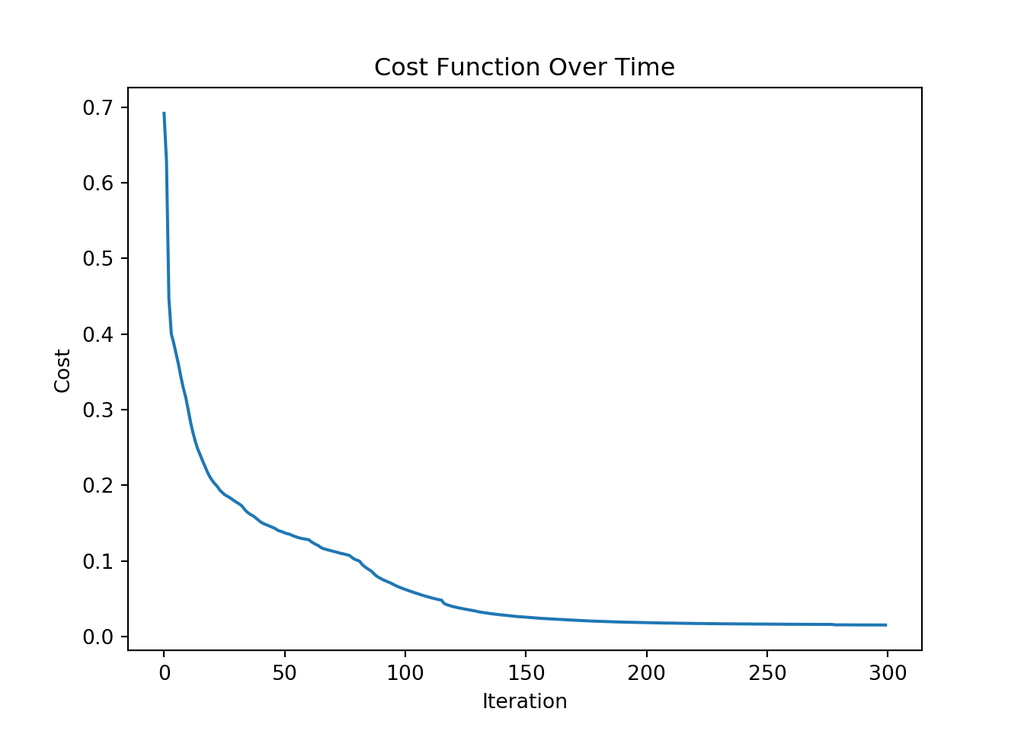

```python
plt.figure()
plt.plot(costs[::100])
plt.title("Cost Function Over Time")
plt.xlabel("Iteration")
plt.ylabel("Cost")
```

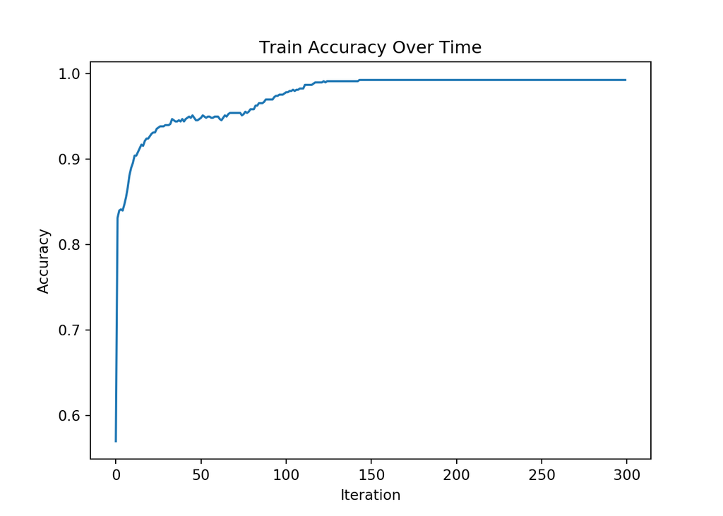

```python
plt.figure()
plt.plot(acc[::100])
plt.title("Train Accuracy Over Time")
plt.xlabel("Iteration")
plt.ylabel("Accuracy")
```

Compare to a GLM.

```python
h_test, z_test, hz_test = forward_prop(X_test, relu, sigmoid, wb)
print("NN Test Accuracy: ", np.mean(decision_boundary(h_test) == Y_test))
```

```
NN Test Accuracy:  0.7966666666666666
```

```python
glm = LogisticRegression(C=1).fit(X_train, Y_train.reshape(-1, ))
print(wb['bias0'], wb['Weight0'].reshape(-1, ))
```

```
[[ 1.16577873 -1.32920517 -1.90658377 -0.66651555  0.26205723  2.64674276
  -0.7879502   1.13581158  0.6791      2.61996714]] [-1.27477688e+00 -2.54686388e-01 -2.16522491e-01 -3.89724646e-01
 -2.67312700e+00 -5.62604437e-01  1.05194885e+00  1.08016045e+00
  1.25659405e+00 -5.21858149e-02 -8.41658371e-02 -2.25692186e+00
  9.86397856e-01 -1.02926199e+00 -4.02456519e-01 -4.15845104e-01
  2.51122566e-03 -8.43546787e-01 -1.51521282e+00 -1.36093793e+00
 -9.92447204e-02  7.73719192e-01 -3.05754435e-02  1.50682053e-01
  2.60320443e-01 -4.41109565e-01 -2.00259425e+00 -1.57529233e+00
 -1.76733308e+00  1.05862950e-01 -1.56539296e+00  3.97968866e-01
  1.11860461e+00 -1.00937246e-01  3.68006421e-02 -9.99491178e-01
 -6.77017361e-01  1.30331208e+00  1.56388116e+00 -9.37038323e-01
 -1.02292249e+00  3.70328552e-01 -4.37785524e-02 -1.38502022e+00
 -2.84396375e+00 -6.97984146e-01  5.51766099e-01 -1.34565114e+00
 -3.19304517e-01 -3.25109309e-01  3.24852891e+00  2.49859972e+00
 -2.10606697e+00  1.92746380e+00  6.52032490e-01  2.89908454e+00
  1.36807448e+00 -1.87895702e+00 -8.59729730e-01  3.09585497e+00
 -5.46855661e-01  1.43027251e+00 -4.58481094e-02  3.94743616e-01
  1.76815656e-01 -8.84226393e-02 -4.05518677e-01  1.24114557e+00
  1.63293697e+00  1.38438710e-01 -3.66950382e-01 -9.59562134e-02
 -2.01080840e-01 -1.40673926e+00 -1.94686518e+00  2.79876031e-01
  8.91225016e-01  1.26654562e+00  1.15170602e+00 -2.66654680e-01]
```

```python
print(glm.intercept_, glm.coef_.reshape(-1, ))
```

```
[0.17543653] [ 0.12182548  1.08136666  0.05496747 -0.28701322 -0.07183486 -0.45580601
 -0.49023946  0.04989209]
```

```python
print("GLM Test Accuracy: ", glm.score(X_test, Y_test.reshape(-1, )))
```

```
GLM Test Accuracy:  0.8233333333333334
```

Compare to a GLM with only 1 hidden layer and a depth of 1

```python
wb, hz, costs, acc = dnn(X=X_train,
                           Y=Y_train,
                           actf=relu,
                           outf=sigmoid,
                           costf=cross_entropy_binary,
                           dactf=relu_der,
                           doutf=sigmoid_der,
                           dcostf=cross_entropy_binary_der,
                           eval_size=5000,
                           hidden_nodes=[1],
                           output_nodes=1,
                           scale_weights=0.1,
                           num_iterations=30000,
                           optimizer='adam',
                           optimizer_args={'learning_rate': 0.001,
                                           'beta1': 0.9,
                                           'beta2': 0.999,
                                           'eps': 1e-8},
                           print_cost=True,
                           random_state=42)
```

```
Iteration 0: Cost: 0.691905, Acc: 0.697143
Iteration 5000: Cost: 0.434251, Acc: 0.824286
Iteration 10000: Cost: 0.434249, Acc: 0.824286
Iteration 15000: Cost: 0.434249, Acc: 0.824286
Iteration 20000: Cost: 0.434249, Acc: 0.824286
Iteration 25000: Cost: 0.434249, Acc: 0.824286
```

```python
h_test, z_test, hz_test = forward_prop(X_test, relu, sigmoid, wb)
print("NN Test Accuracy: ", np.mean(decision_boundary(h_test) == Y_test))
```

```
NN Test Accuracy:  0.82
```

```python
print(wb['bias0'], wb['Weight0'].reshape(-1, ))
```

```
[[1.96005168]] [-0.0990918  -0.62128399 -0.05987373  0.70862086  0.0497925   0.69870264
  0.74927225 -0.02965444]
```

```python
print(glm.intercept_, glm.coef_.reshape(-1, ))
```

```
[0.17543653] [ 0.12182548  1.08136666  0.05496747 -0.28701322 -0.07183486 -0.45580601
 -0.49023946  0.04989209]
```

```python
print("GLM Test Accuracy: ", glm.score(X_test, Y_test.reshape(-1, )))
```

```
GLM Test Accuracy:  0.8233333333333334
```

Compare to a GLM with no hidden layers (notice how it is equivalent to the GLM result). As a side note, some NN formulations do not include an activation on the output layer. For a binary classification, an activation function on the output layer is generally recommended, but this may be up for debate. For a neural network modeling a gaussian output, the activation function on the final layer is not required, and usually not recommended for a gaussian output. A layer that has no activation function is typically referred to as a linear activation, such that $f(x)=x$, though it is possible for another linear transformation to be used.

```python
wb, hz, costs, acc = dnn(X=X_train,
                           Y=Y_train,
                           actf=relu,
                           outf=sigmoid,
                           costf=cross_entropy_binary,
                           dactf=relu_der,
                           doutf=sigmoid_der,
                           dcostf=cross_entropy_binary_der,
                           eval_size=5000,
                           hidden_nodes=[],
                           output_nodes=1,
                           scale_weights=0.1,
                           num_iterations=30000,
                           optimizer='adam',
                           optimizer_args={'learning_rate': 0.001,
                                           'beta1': 0.9,
                                           'beta2': 0.999,
                                           'eps': 1e-8},
                           print_cost=True,
                           random_state=42)
```

```
Iteration 0: Cost: 0.770873, Acc: 0.302857
Iteration 5000: Cost: 0.442941, Acc: 0.821429
Iteration 10000: Cost: 0.442941, Acc: 0.821429
Iteration 15000: Cost: 0.442941, Acc: 0.821429
Iteration 20000: Cost: 0.442941, Acc: 0.821429
Iteration 25000: Cost: 0.442941, Acc: 0.821429
```

```python
h_test, z_test, hz_test = forward_prop(X_test, relu, sigmoid, wb)
print("NN Test Accuracy: ", np.mean(decision_boundary(h_test) == Y_test))
```

```
NN Test Accuracy:  0.8233333333333334
```

```python
print(wb['bias0'], wb['Weight0'].reshape(-1, ))
```

```
[[0.17715777]] [ 0.12396107  0.82470629  0.05543543 -0.67590747 -0.07352213 -0.65704895
 -0.67664165  0.05061512]
```

```python
print(glm.intercept_, glm.coef_.reshape(-1, ))
```

```
[0.17543653] [ 0.12182548  1.08136666  0.05496747 -0.28701322 -0.07183486 -0.45580601
 -0.49023946  0.04989209]
```

```python
print("GLM Test Accuracy: ", glm.score(X_test, Y_test.reshape(-1,)))
```

```
GLM Test Accuracy:  0.8233333333333334
```

It should be noted that linear activation functions are generally avoided because they do not generalize to the non-linear functions we really care about, which is the reason we chose a neural network in the first place. Consider the example above where only linear activations are used.

$$X_{m\times n} \beta_{1_{n\times p}} \beta_{2_{p\times k}} h_{k \times c} = Y$$
$$X_{m\times n} (\beta_{1_{n\times p}} \beta_{2_{p\times k}} h_{k \times c}) = Y$$
$$X_{m\times n} (\beta_{n \times c}) = Y$$

$$X \beta = Y$$

If each layer uses linear activation functions, then the solution can be completely reduced to a simple linear model. Or, if there were only linear activation functions except for the output layer, the model can be reduced completely to a GLM.

## Multiclass Neural Networks

The concept is the same as above, and the general math is the same, but we need to update some of our functions. For example, the sigmoid function will be updated to it’s multiclass equivalent, the softmax function, and the cross-entropy function will be generalized.

The sigmoid function is as follows:

$$f(x) = \frac{e^{x}}{1+e^x} = \frac{1}{1 + e^{-x}}$$

The sigmoid function is used in binary classification because it has the following equivalence property:

$$1 = \frac{1}{1+e^x} + \frac{1}{1 + e^{-x}}$$

This implies that for any value of $x$, $f(-x) = 1 - f(x)$. This makes it a good candidate for binary classification because it ensures that $P(Y=1) = 1 - P(Y=0)$, which follows the laws of probability (i.e. that the total probability of all simple events, (which in the binary case is the success or failure of the event) must sum to 1). Also note that the sigmoid function can be completely derived from the link function in the bernoulli GLM, which in turn ties it to the bernoulli likelihood (i.e. $log(\frac{\hat{p}}{1-\hat{p}}) = X\hat{\beta}$ where $\hat{p}$ is $P(Y=1)$, and is algebraically rearranged to be $p = \frac{1}{1+e^{-X\beta}}$,such that $L(\hat{p}| Y) = \prod f(Y|\hat{p}) = \hat{p}^Y (1-\hat{p})^{1-Y}$).

In this manner, a logistic regression model is built under the assumption of the independence of irrelevant alternatives theorem. For this context, that means that if we model $P(Y=1)$, then we don’t need to explicitly include $P(Y=0)$ because by solving for $P(Y=1)$, we have all of the information related to $P(Y=0)$. This reasoning is related to why $k-1$ dummy binary features are generated from a variable with $k$ categories in Linear regression (though it is worth noting that in the particular case of Linear regression, it is not just because of the irrelevant alternatives theorem. Actually creating $k$ dummy variables makes $X^TX$ singular and not invertible, which makes the equation unsolvable).

The sigmoid equivalence equation can also be written as

$$1 = \frac{e^{-x}}{1+e^{-x}} + \frac{1}{1 + e^{-x}} = \frac{e^{x}}{1+e^{x}} + \frac{1}{1 + e^{x}}$$

which leads us to the first generalization of the sigmoid function, the multinomial logit model, or multinomial logistic regression. Suppose we are modeling $K$ classes or outcomes. In a multinomial logit model, all event probabilites must sum to one, same as in the binary case. Thus:

$$P(Y=K) = 1 - \sum_{i=1}^{K-1}P(Y = i) = \frac{1}{1+\sum_{i=1}^{K-1}e^{\beta_i X}}$$

and $P(Y=j)$ where $j < K$ is

$$P(Y=j) = \frac{e^{\beta_j X}}{1+\sum_{i=1}^{K-1}e^{\beta_i X}}$$

In matrix form, the multnomial logit model has the form $Y_{n \times K-1} = \sigma^{-1}(X_{n \times m}\beta_{m \times K-1})$, where $\sigma$ is the link function. The multinomial logit model explicitly models $K-1$ classes and has $m \times (K-1)$ coefficients, which can be thought of as $K-1$ separate regression models. The probability of the $K^{th}$ class is known by modeling the other $K-1$ probabilities, same as the logistic regression binary case.

The softmax equation can be written succinctly as:

$$P(Y=j) = f(x_j) = \frac{e^{x_j}}{\sum_{j=1}^{K}e^{x_j}}$$

Notice that the softmax function is not a scalar function, but rather a vector function. Therefore, it’s derivative is a jacobian matrix.

### Jacobian

A scalar function is defined as a function that has a single output, given any number of inputs. A vector function is a function that produces multiple outputs for any number of inputs. As we saw before the derivative of a scalar function is a gradient (i.e. a vector of partial derivatives with respect to each input). The dervative of a vector function is a jacobian matrix, which is a matrix of partial derivatives with respect to each input and output. Below is a trivial example to help solidify the difference:

Gradient:

$$f(x, y) = 3x^2y^2 + 2xy + 4x - y$$

$$f'(x, y) = \left[ \frac{df}{dx}, \frac{df}{dy} \right] = \left[ 6xy^2 + 2y + 4, 6x^2y + 2x - 1\right]$$
Jacobian:

$$f(x, y) = \left[ x^2y^3, 2x + y \right]$$

$$f'(x, y) = \left[{\begin{array}{c} \nabla f_1(x,y) \\ \nabla f_2(x,y) \\ \end{array}} \right] = \left[{\begin{array}{cc} \frac{df_1}{dx} & \frac{df_1}{dy} \\ \frac{df_2}{dx} & \frac{df_2}{dy} \\ \end{array}} \right] = \left[{\begin{array}{cc} 2xy^3 & 3x^2 y^2 \\ 2 & 1 \\ \end{array}} \right]$$

Notice that the jacobian matrix is formed from the vector of each function’s gradient.

The softmax equation for two inputs $x, y$ is summarized as follows:

$$f(x, y) = \left[\frac{e^{x}}{e^{x} + e^{y}}, \frac{e^{y}}{e^{x} + e^{y}} \right]$$

Since the softmax equation is a vector function, it’s jacobian for two inputs, $x$ and $y$ is as follows:

$$f'(x, y) = \left[{\begin{array}{cc} \frac{df_1}{dx} & \frac{df_1}{dy} \\ \frac{df_2}{dx} & \frac{df_2}{dy} \\ \end{array}} \right] = \left[{\begin{array}{cc} \frac{e^{x}(e^{x} + e^{y}) - e^{x}e^{x}}{(e^{x} + e^{y})^2} & \frac{-e^{x}e^{y}}{(e^{x} + e^{y})^2} \\ \frac{-e^{y}e^{x}}{(e^{x} + e^{y})^2} & \frac{e^{y}(e^{x} + e^{y}) - e^{y}e^{y}}{(e^{x} + e^{y})^2} \\ \end{array}} \right]$$

$$f'(x, y) = \left[{\begin{array}{cc} \frac{e^{x}e^{x} + e^{x}e^{y} - e^{x}e^{x}}{(e^{x} + e^{y})^2} & \frac{-e^{x}e^{y}}{(e^{x} + e^{y})^2} \\ \frac{-e^{y}e^{x}}{(e^{x} + e^{y})^2} & \frac{e^{y}e^{y} + e^{x}e^{y} - e^{y}e^{y}}{(e^{x} + e^{y})^2} \\ \end{array}} \right] = \left[{\begin{array}{cc} f_1(x, y)f_2(x, y) & -f_1(x, y)f_2(x, y) \\ -f_2(x, y)f_1(x, y) & f_2(x, y)f_1(x, y) \\ \end{array}} \right]$$

In this simple two-class example, the jacobian simplifies to the first softmax function multiplied by the second softmax function (on the diagonal). However, it should be generalized to reflect what is really happening in higher dimensions, as shown below:

$$f'(x, y) = \left[{\begin{array}{cc} f_1(x, y)f_2(x, y) & -f_1(x, y)f_2(x, y) \\ -f_2(x, y)f_1(x, y) & f_2(x, y)f_1(x, y) \\ \end{array}} \right] = \left[{\begin{array}{cc} f_1(x, y)(1-f_1(x, y)) & -f_1(x, y)f_2(x, y) \\ -f_2(x, y)f_1(x, y) & f_2(x, y)(1-f_2(x, y)) \\ \end{array}} \right]$$
The intuitive explanation for what is happening above is that the values on the diagonal of the jacobian represent the probabilities $f_i(x, y)$ that are being multiplied by the sum of the non $i^{th}$ probabilities, or, the probability not captured by $f_i(x, y)$ for the $i^{th}$ diagonal. On the off diagonal, it is the negative of the $i^{th}$ and $j^{th}$ probabilities multiplied together. A $3\times 3$ result would be as follows:

$$f'(x,y,z) = \left[{\begin{array}{ccc} f_1(x, y, z)(1-f_1(x, y, z)) & -f_1(x, y, z)f_2(x, y, z) & -f_1(x, y, z)f_3(x, y, z) \\ -f_2(x, y, z)f_1(x, y, z) & f_2(x, y, z)(1-f_2(x, y, z)) & -f_2(x, y, z)f_3(x, y, z) \\ -f_3(x, y, z)f_1(x, y, z) & -f_3(x, y, z)f_2(x, y, z) & f_3(x, y, z)(1-f_3(x, y, z)) \end{array}} \right]$$

The jacobian is sometimes referenced with respect to the kronecker delta, such that:

$$\delta_{ij} =
\begin{cases}
0 & \text{if } i \neq j \\
1 & \text{if } i = j
\end{cases}$$

$$f'(\textbf{x}) = f_i(\textbf{x})(\delta_{ij} - f_j(\textbf{x}))$$

Note that the above jacobian is with respect to only one observation, that is, only one $(x, y)$ pair, where $x$ and $y$ would be (together) considered one observation from the output layer (before activation). To use the softmax as a cost function in a neural network, you must calculate the jacobian with respect to each observation, so there are two options to proceed. The first method would be to simply loop through each observation and plug the values into the jacobian as calculated above. The other option is to calculate the full jacobian matrix, which ends up being matrices within a matrix (also called a block matrix).

Let $f(\textbf{x}_p)$ be the softmax function applied to the $p^{th}$ observation, such that each output is a $1 \times c$ vector of softmax probabilites (one for each class in the observation), let $\sigma = \left[{\begin{array}{c} f(\textbf{x}_1) \\ f(\textbf{x}_2) \\ ... \\ f(\textbf{x}_p) \end{array}} \right]$ be a vector of softmax outputs for each observation, and let $\textbf{J}$ be a $c \times c$ matric representing the jacobian of the respective softmax function. Then:

$$\sigma' = \left[{\begin{array}{cccc} \textbf{J}_{f(\textbf{x}_1)} & \textbf{0} & ... & \textbf{0} \\ \textbf{0} & \textbf{J}_{f(\textbf{x}_2)} & ... & \textbf{0} \\ ... & ... & ... & ... \\ \textbf{0} & 0 & ... & \textbf{J}_{f(\textbf{x}_p)} \end{array}} \right]$$

The derivatives on the off diagonal of the block matrix are the $\textbf{0}$ matrix of size $c \times c$. This is due to the fact that the observations are independent, and so the softmax derivative of $f(\textbf{x}_1)$ with respect to $f(\textbf{x}_2)$ isn’t relevant to the solution and goes to zero.

The full derivation is not provided here, but it sufficient to say that the jacobian of the softmax, when combined with a cross entropy cost function for the output layer, reduces to a much simpler equation, which allows computer programs to side-step computing the jacobian altogether when performing multinomial classification problems using softmax and cross entropy. Borrowing notation for the output layer and cost function derivative from the backpropagation algorithm, the derivative works out to be $\psi ' (Y, Z_j) \times \sigma_{j} ' (Z_{j-1} W_j + b_j) = Z_j - Y$, or in other words, it reduces to the $Y$ being subtracted from the predicted values for $Y$.

### Sigmoid for Multiple Classification

It’s also worth noting that sigmoid can also be used in the multiclass case on it’s own, and in this situation, you simply apply the sigmoid function (and it’s derivative during backpropagation) to each element in the weight matrix. In this case, it does not form a probability distribution (i.e. the sum of sigmoid activated values for each observation will not sum to 1), but it can perform multiple classification nonetheless (for example, you could decide that the highest activated value is the single predicted class). Using clever thresholding, this approach can be good for multiple classification where an observation may be classified as multiple things (think of finding multiple objects in an image). This is because applying a sigmoid function to each of the values represents a type of existence for each class (i.e. what is the probability of the observation belonging to this class, and only this class?). By using thresholding (value of 0.5 for example), an observation (with 4 classes) could be classified as [0, 0, 1, 1]. In other words, with a sigmoid activation, you are answering the question “to which of these classes does the observation belong, all of them, some of them, or none of them?” With softmax, there can only be one right answer in the classification sense, so the probabilities must sum to one and the class with the highest probability represents the class that is most likely associated with that observation. When the classes are mutually exclusive sets, then softmax is a good application. If the classes are not mutually exclusive, then use a sigmoid function. Another way to say it is that the sigmoid function is only interested in providing a yes/no answer for a particular class, while the softmax function gives each class an answer with respect to all the other classes. For softmax, if the model can’t find an answer, each class will have a probability of $1/c$, where $c$ is the number of classes.

## Regression and Multivariate Regression

There isn’t anything new to add here, except to say that for a regression or multivariate regression problem, the output layer has no activation function, or better said, the output layer has a linear activation function. Any linear function will reduce to something more compact (as shown earlier), so unless there is a non-linear function that helps you achieve an output resembling a gaussian distribution or something similar, there isn’t much utility in addaing an activation function to the output layer. Typical cost functions for a numeric case would be RPMSE/MSE or L1 loss, etc.

## Improving the model

Now that we’ve graduated from binary classification and have all the basic building blocks, we can improve the model through regularization techniques and batching.

### Regularization

This is no different than applying regularization to a GLM. Regularizing the weight matrices is the same as regularizing the regression coefficients. Also, similarly to a GLM, the bias weights are not typically regularized, though in both a GLM and a NN, you are free to do so.

In the case of the weights, no change is made to the weights in forward propagation. The penalty is added to the cost function, like so:

$$cost = \psi(Y, \sigma(Z)) + \sum_{i=1}^l \lambda||\textbf{W}_i||^p_p$$

where $\psi$ is the cost function, $Z$ is the affine transformation ($XW+b$) of the last layer, $\sigma$ is the output layer activation function, $\lambda$ is the penalty strength, $p$ is the $l_p$ norm, and $\textbf{W}_i$ are the weight matrices for $i^{th}$ layer. $||X||_p$ is referred to as the matrix norm, where $p$ represents the type of norming function being used on $X$. In the regularization equation above, the upper $p$ ($||W_i||^p$) is an exponent outside the function. Sometimes $\lambda$ is scaled by $\frac{1}{p}$, which helps the weights tend to zero during the training process, but it is just a scale, and increasing/decreasing lambda could have the same effect. It also gives a meaningful interpretation to the norm derivative in backpropagation such that the weight update in gradient descent becomes $w := w - \alpha(\nabla w + \lambda w)$. This adjustment then makes the gradient update equal to a direct scaling of the weights.

The norm function is evaluated as follows:

$$||\textbf{x}||_p = (\sum_{i=1}^n|x_{i}|^{p})^{\frac{1}{p}}$$

and it’s derivative:

$$\frac{d}{dx_j}||\textbf{x}||_p = |x_j|^{p-1} sgn(x) \left[ \sum_{i=1}^n |x_i|^p\right]^{\frac{1}{p}-1}$$
Without the exponent, the norm function is:

$$||\textbf{x}||_p^p = \sum_{i=1}^n|x_{i}|^{p}$$

And the derivative is:

$$\frac{d}{dx_j}||\textbf{x}||_p^p = p|x_j|^{p-1} sgn(x_j)$$

To account for weight regularization in backpropagation, simply add the derivative of the $l_p$ norm function. This would be added to steps 2.3.1.3-4 in algorithm 3

### Dropout

(Coming Soon)

### Batch Normalization

(Coming Soon)

## Appendix

### Code

Other than the code provided here, a more involved example can be found in the `tsdst` package, which can be installed with pip. The documentation can be found [here](https://tomwerner5.github.io/tsdst/Descriptions.html).

### Identifiable

For a model to be identifiable, it must be able to produce unique probabilities for each unique set of weights (given a set of inputs). From a parametric model standpoint, this would mean that we can make inferences about the underlying distribution the data was (assumed) to be generated from. If the model is not identifiable, then inference is not possible (or at least not credible) since there are two or more distributions (i.e. sets of parameters for some underlying distribution that the data was sampled from) that can exactly equivalently describe the data. For most linear models (and most MLE examples in classical statistics), the models are identifiable. In OLS, this is particularly true since the maximum likelihood estimate is a unique solution for a given input $X$. In OLS, since there is exactly one coefficient for each independent variable in $X$ (not including the intercept), so as long as the matrix $E(XX^T) = \frac{XX^T}{n}$ is invertible, the solution is identifiable (due to the uniqueness of invertible matrices).

The same is not true for neural networks. Because the layers go through various linear transformations, the network is by definition non-identifiable since there will be more than one combination of weights that will lead to the exact same solution. For example, consider matrices $X$, $W_1$, $W_2$, and $W_3$, where X is the input to the network. Assuming Linear activation functions (and a constant column in $X$ for bias), $\hat{Y} = XW_1 W_2 W_3$, such that a simple reversal of the signs of the elements of $W_1$ and $W_2$ will produce the exact same output Y. In other words, a change the the weights made in $W_1$ can be reversed in $W_2$ or $W_3$ such that outputs of equal likelihood can be generated. Observe:

```r
X = cbind(rnorm(10), rnorm(10))
W_1 = matrix(rnorm(2*4), nrow=2)
W_2 = matrix(rnorm(4*3), nrow=4)
W_3 = matrix(rnorm(3*1), nrow=3)

y_hat1 <- X%*%W_1%*%W_2%*%W_3
y_hat2 <- X%*%-W_1%*%W_2%*%-W_3

all(y_hat1 == y_hat2)
```

```
[1] TRUE
```

Identifiability implies that there is strong convexity (i.e. there is a single unique minimum and unique minimizer). Because neural networks are often not identifiable, their loss functions are also not convex (or at least not strongly convex). This tendency is also what can cause neural networks to overfit, where in this context they find a solution at a minimum, but since the solution is not identifiable, it is not the solution that generalizes to the unseen data.

In practice, the identifiability of a neural network may not be important. Because the black-boxy nature of a neural network is difficult to interpret on it’s own, creating an identifiable network is not as much of a priority. Generally, black-box methods are sought out for their accuracy or ability to approximate some function.

### Cross-entropy

The relationship between cross-entropy and likelihood functions (specifically the bernoulli likelihood in this case) is straightforward, but can be easy to miss.

While the definition varies across ML domains, Cross-entropy in general is a method of measuring the difference of information between two probability distributions (i.e. a way of measuring how similar they are). In our context, cross entropy is the difference between our observed values (which can be viewed as a probability distribution where every probability is either 0 or 1, since every value is known and thus has an extreme probability) and the predicted values (which are actual probabilities since the true values are unknown). Since we are interested in predicting values that follow a bernoulli distribution, the cross entropy takes the form of the bernoulli negative log-likelihood.

#### From Log-likelihood

Deriving binary cross-entropy from bernoulli log-likelohood:

$$log(L(\hat{p}| Y)) = log(\prod_{i=1}^N f(Y|\hat{p}))$$

$$log(L(\hat{p}| Y)) = \sum_{i=1}^N log(f(y_i|\hat{p}_i) = \sum_{i=1}^N log( \hat{p}_i^{y_i} (1-\hat{p}_i)^{1-y_i})$$

$$log(L(\hat{p}| Y)) = \sum_{i=1}^N y_i log(\hat{p}_i) + (1-y_i) log(1-\hat{p}_i)$$

For gradient descent (and variants), we are trying to minimize the negative cost (i.e. in this case, higher log-likelihood is better, so lower negative log-likelihood is also better), so the function is multiplied by $-1$.

$$-log(L(\hat{p}| Y)) = -\left[ \sum_{i=1}^N y_i log(\hat{p}_i) + (1-y_i) log(1-\hat{p}_i) \right]$$

And thus, we arrive at cross-entropy.

Cross-entropy can also be derived as the sum of shannon entropy and Kullback-Leibler (KL) divergence.

Shannon Entropy:

$$H(p) = -\sum_{x \in X} p(x)log(p(x))$$

KL Divergence:

$$D_{KL}(p || q) = \sum_{x \in X} p(x)log \left( \frac{p(x)}{q(x)} \right)$$
Then:

$$H(p, q) = H(p) + D_{KL}(p || q) = -\sum_{x \in X} p(x)log(p(x) + \sum_{x \in X} p(x)log \left( \frac{p(x)}{q(x)} \right)$$

$$H(p, q) = \sum_{x \in X} \left( p(x)log \left( \frac{p(x)}{q(x)} \right) - p(x)log(p(x)) \right)$$

$$H(p, q) = \sum_{x \in X} \left( p(x)(log (p(x))-log(q(x))) - p(x)log(p(x)) \right)$$

$$H(p, q) = \sum_{x \in X} p(x)\left(log (p(x))-log(q(x)) - log(p(x)) \right)$$

$$H(p, q) = \sum_{x \in X} p(x)\left(-log(q(x)) \right)$$

$$H(p, q) = \sum_{x \in X} p(x)\left(-log(q(x)) \right) = -\sum_{x \in X} p(x)log(q(x))$$

The above equation is the general form of cross entropy, meaning it generalizes to any number of classes for a classification problem. Now take note that $p(x)$ and $q(x)$ are probability distributions under the same events $x$. We can change the $x$ in notation here to $y$, since that’s what we’re really interested in when performing machine learning. So for binary classification, this equates to $p(y)$ being the probability of observation $y$ being a success or failure. Also, y is a conditional probability is our case, so it would be more correct to write $p(y|x, \beta)$, but for simplicity, I’ll just refer to it as $p(y)$. Since we already know the outcome of the event for the training observations, $p(y=1)=1$ or $p(y=0)=0$. Then, $q(y)$ represents the probability that our model prediction ($\hat y$) of observation $y$ is a success or failure. The distribution for each observation $y$ is a bernoulli distribution such that the probability $p$ is an element of $\left\{ y, 1-y \right\}$, and the probability $q$ is an element of $\left\{ \hat{y}, 1-\hat{y} \right\}$. Then, for binary cross-entropy, $H(p, q)$ becomes:

$$H(p, q) = -\sum_{x \in X} p(y_x=1, 0)log(q(\hat{y}_x=1, 0)) = -\sum_{x \in X} y_x log(\hat{y}_x) + (1-y_x)log(1-\hat{y_x})$$
If there were more classes of interest, this can easily be extended to

$$H(p, q) = -\sum_{x \in X} p(y_x=c_1, c_2, c_3)log(q(\hat{y}_x=c_1, c_2, c_3)) = -\sum_{x \in X} \left[ y_{c_1 x} log(\hat{y}_{c_1 x}) + y_{c_2 x} log(\hat{y}_{c_2 x}) + y_{c_3 x} log(\hat{y}_{c_3 x}) \right]$$
and so on.

## The End

If anyone has any questions, notices any errors, etc., please reach out. I welcome feedback.